# Logistic Regression, Stochastic Gradient Descent and Support Vector Machine

## IV. Interpret Support Vector

```python
#{'C': 75, 'gamma': 0.01, 'kernel': 'rbf'}
svm_clf = SVC(C=75, kernel='rbf', gamma=.01) # get object
svm_clf.fit(X_train, y_train)  # train object

# look at the support vectors
print(X_train.shape)
print(svm_clf.support_vectors_.shape)
print(svm_clf.support_.shape)
print(svm_clf.n_support_ )
#svm_clf.support_
svm_clf.support_
```

```
SVC(C=75, gamma=0.01)
```

```
(14622, 31)
(4649, 31)
(4649,)
[ 855 1481   22 2291]
```

```
array([    1,     6,    37, ..., 14603, 14611, 14614], dtype=int32)
```

```python
# Now let's do some different analysis with the SVM and look at the instances that were chosen as support vectors

# grabe the rows that were selected as support vectors (these are usually instances that are hard to classify)
# make a dataframe of the training data
df_tested_on = df_pred_pos.iloc[train_index].copy() # saved from above, the indices chosen for training
# now get the support vectors from the trained model
df_support = df_tested_on.iloc[svm_clf.support_,:].copy()
df_orignal = df_pred_pos.copy()
```

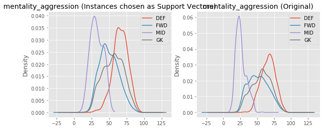

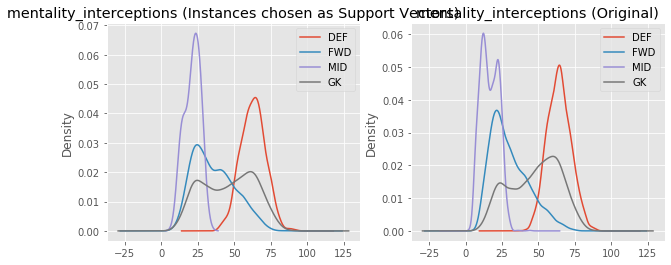

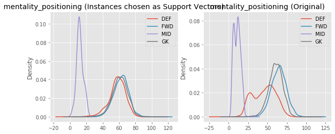

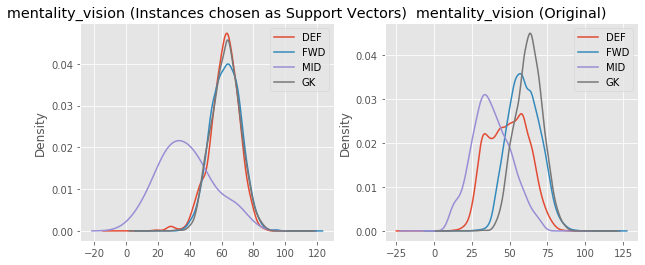

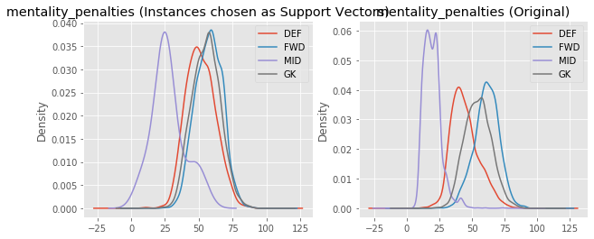

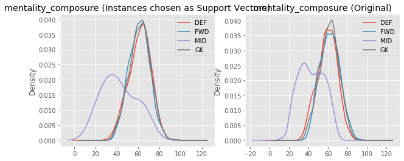

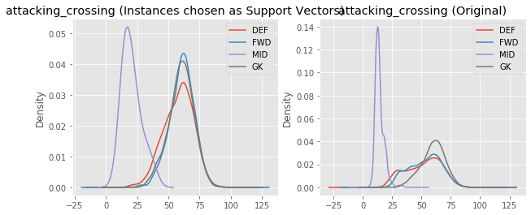

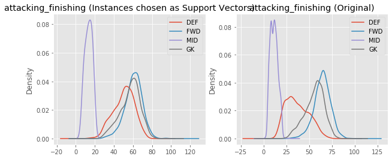

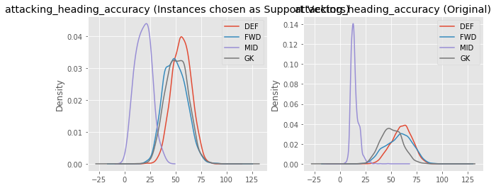

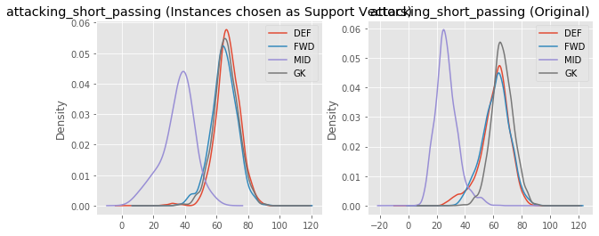

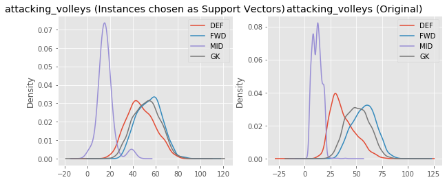

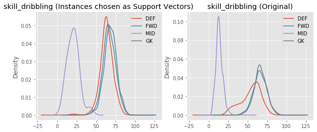

[14 more figures not shown]

```python
# now lets see the statistics of these attributes
from pandas.plotting import boxplot;

plt.rcParams.update({'figure.max_open_warning': 0})
# group the original data and the support vectors
df_grouped_support = df_support.groupby(['preferred_position_cat']);
#df_grouped_support
df_grouped = df_orignal.groupby(['preferred_position_cat']);

# plot KDE of Different variables
l=df_mental_attr.append(df_attacking_attr).append(df_skill_attr).append(df_movement_attr).append(df_power_attr)

#vars_to_plot = ['skill_dribbling','mentality_aggression'];
for v in l:
    f =plt.figure(figsize=(10,4));
    # plot support vector stats
    p = plt.subplot(1,2,1);
    ax = df_grouped_support[v].plot.kde() ;
    a = plt.legend(['DEF', 'FWD', 'MID', 'GK']);
    a = plt.title(v+' (Instances chosen as Support Vectors)');

    # plot original distributions
    p1 =plt.subplot(1,2,2);
    ax = df_grouped[v].plot.kde();
    a =plt.legend(['DEF', 'FWD', 'MID', 'GK']);
    a =plt.title(v+' (Original)');
```

Since we have a total of 31 features, we end up with 31 dimensions. In the above plots, we are comparing the support vectors against the original class boundary by one dimension at a time. Taking a look at a mentality_aggression, we see the support vectors increase the class boundary. But for mentality_positioning and mentality_composure, the support vectors converge due to closer class boundary. This is due to the fact that the support vector can only have one boundary.  
Overall, it means that the instances chosen as support vectors always lie along the model / classes’ decision boundary. That is how the instances are selected.

⏫ Table of Contents

# Part C. Conclusion and Discussion

In conclusion, we have studied the LR, SGD and SVM classifcations using the FIFA 20 dataset. With respect to the faster training time, the candidates are LR and SGD algorithms based on their mathematical properties but with lower accuracy.

SVC-SMOTE gave us the best overal f1 score in this study. The downside of this model is the time it takes to refit the best model. But since it is a small dataset, it is not a big issue.

LR is a probabilistic classification model using the sigmoid function, whereas SVC are a more geometric approach that maximise the margins to each class. They are similar in the way that they both can divide the feature space with a decision boundary. It is safe to assume that when compared to LR models, the SVM models are creating a wider margin between classes and generalizing better. Also, based on the cross validation report of the models, we see the f1 score for SVM is higher.

⏫ Table of Contents